# Differential Gene Expression Across a C. albicans Infection Time Course in Planaria

M. LeGro

2026-07-21

## Normalizing and filtering read counts

This picks up from the alignment/`featureCounts` output produced by the alignment Rmd: 18 libraries – three uninfected controls (CP1-CP3) and five post-infection time points (6hpi, 1dpi, 3dpi, 5dpi, 7dpi) with three replicates each. A `DGEList` is built from the raw counts, normalization factors are calculated, low-count genes are filtered (CPM > 0.5 in at least one sample), and the remaining counts are converted to counts-per-million (CPM).

```r
library(tidyverse)  # includes ggplot2, dplyr, readr, etc. -- no need to also load dplyr separately
library(limma)
library(edgeR)
library(RColorBrewer)
library(ComplexHeatmap)
library(circlize)
setwd("/Volumes/PortableSSD/CA_infectionproj/")

analysis_date <- "2026.07.21"  # used to label output files
counts_file <- "2026.07.20_Calbicans_counts_exonfeature.txt"  # written by the alignment Rmd
# Sample -> condition key, defined once here rather than
# maintained in a separate hand-typed metadata file. The
# original PTEN script read a standalone meta.txt and
# matched it to the counts matrix by row position; if the
# two files were ever in a different order, samples would
# be silently mislabeled. Matching by sample_id below
# (rather than trusting row order) removes that risk
# entirely.
sample_metadata <- data.frame(sample_id = c("CP1", "CP2", "CP3",
    "S1", "S2", "S3", "S4", "S5", "S6", "S7", "S8", "S9", "S10",
    "S11", "S12", "S13", "S14", "S15"), condition = factor(c(rep("Control",
    3), rep("6hpi", 3), rep("1dpi", 3), rep("3dpi", 3), rep("5dpi",
    3), rep("7dpi", 3)), levels = c("Control", "6hpi", "1dpi",
    "3dpi", "5dpi", "7dpi")), stringsAsFactors = FALSE)

# Import raw counts
counts_raw <- read.delim(counts_file, row.names = 1)
countsmat <- as.matrix(counts_raw[, setdiff(colnames(counts_raw),
    "Length")])

# Confirm every count column has a matching entry in the
# sample key, then order the metadata to match the counts
# matrix's actual column order (not the other way around)
stopifnot(all(colnames(countsmat) %in% sample_metadata$sample_id))
meta_ordered <- sample_metadata[match(colnames(countsmat), sample_metadata$sample_id),
    ]
meta.f <- meta_ordered$condition

# Build the DGEList. Note this is NOT named `list` (as in
# the original PTEN script) -- `list` is a base R function,
# and overwriting it with a DGEList object would silently
# break any later call to list() for the rest of the R
# session.
dge_list <- DGEList(countsmat, group = meta.f)
dge_list <- calcNormFactors(dge_list)

# Filter out genes with less than 0.5 CPM in every sample
keep <- rowSums(cpm(dge_list) > 0.5) >= 1
dge_list <- dge_list[keep, ]

CPM <- cpm(dge_list$counts)

write.csv(CPM, file = paste0(analysis_date, "_Calbicans_countsCPM.csv"))
```

After filtering, the dataset went from 23347 transcripts to 21895 transcripts in the CPM dataset.

## MDS plot for sample distribution

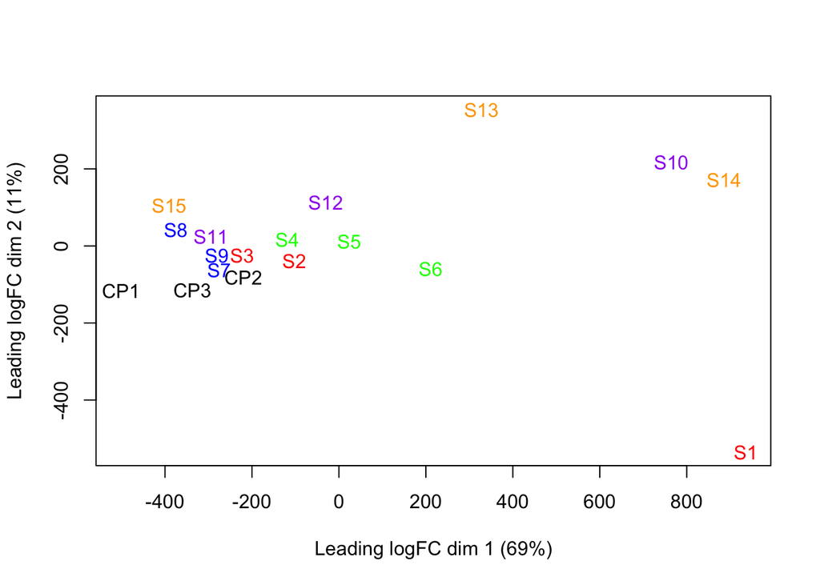

```r
cols <- c("black", "red", "green", "blue", "purple", "orange")
plotMDS(CPM, col = cols[as.numeric(meta.f)])
```

## Fitting the filtered, normalized counts to a linear model

The counts are fit to a linear model with `voomWithQualityWeights` to account for sample-to-sample variation, Bayesian statistics are calculated, and each infected time point is contrasted against the Control group.

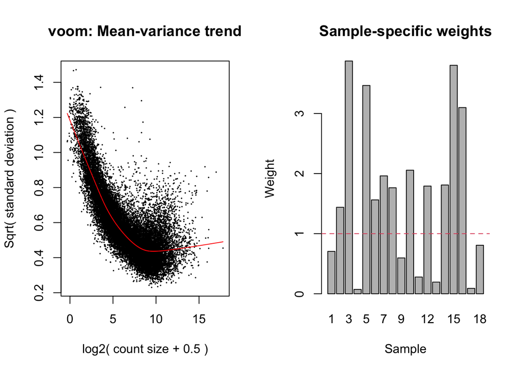

```r
design <- model.matrix(~0 + meta.f)

# Time point labels start with a digit (6hpi, 1dpi, ...),
# which isn't a syntactically valid R name -- make.names()
# prefixes those with 'X' (6hpi -> X6hpi, etc.), which is
# what makeContrasts requires of the design matrix's column
# names. This replaces the backtick approach, which turned
# out not to be enough: makeContrasts validates the
# design's column names themselves before it even parses
# the contrast expressions, so quoting the names in the
# formula doesn't get around it.
colnames(design) <- make.names(levels(meta.f))  # Control, X6hpi, X1dpi, X3dpi, X5dpi, X7dpi

v <- voomWithQualityWeights(dge_list, design = design, normalize.method = "none",
    plot = TRUE)
```

```r
vfit <- lmFit(v, design = design)
vfit <- eBayes(vfit)

# `levels = design` is passed here (the actual design
# matrix), rather than the raw grouping factor as in the
# original script -- that's the usage limma's docs
# describe, and it removes a fragile dependency on the
# factor's levels happening to match the design's column
# names exactly.
contrast_matrix <- makeContrasts(X6hpi - Control, X1dpi - Control,
    X3dpi - Control, X5dpi - Control, X7dpi - Control, levels = design)

timepoints <- c("6hpi", "1dpi", "3dpi", "5dpi", "7dpi")
colnames(contrast_matrix) <- paste0(timepoints, "_vs_Control")

vfit <- contrasts.fit(vfit, contrasts = contrast_matrix)
vfit <- eBayes(vfit)

results <- decideTests(vfit)

timepoints <- c("6hpi", "1dpi", "3dpi", "5dpi", "7dpi")

# One topTable per contrast, built in a loop instead of
# five near-identical lines -- adding or removing a time
# point later only means editing the `timepoints` vector.
toptables <- setNames(lapply(seq_along(timepoints), function(i) topTable(vfit,
    coef = i, number = Inf, sort.by = "P")), timepoints)
toptable_all <- topTable(vfit, number = Inf)

for (tp in timepoints) {
    write.csv(toptables[[tp]], file = paste0(analysis_date, "_Calbicans_toptable_",
        tp, "-Control.csv"))
}
write.csv(toptable_all, file = paste0(analysis_date, "_Calbicans_toptable_allcoefs.csv"))
```

*Note: `number = Inf` is used instead of a hard-coded large number (the original used `number = 300000`, a number picked to safely exceed the transcript count) so every gene is returned regardless of dataset size.*

## Calculating z-scores and merging with topTables

```r
# scale() computes column-wise statistics, so the matrix is
# transposed to put genes in columns, scaled (z-scored per
# gene across samples), then transposed back so genes are
# rows and samples are columns again -- same approach as
# before, just commented so the reason for the
# double-transpose is clear on a re-read.
CPMz <- scale(t(CPM), center = TRUE, scale = TRUE)
CPMzt <- t(CPMz)

write.csv(CPMzt, file = paste0(analysis_date, "_Calbicans_cpmzscore_all.csv"))

merged <- setNames(lapply(timepoints, function(tp) merge.data.frame(toptables[[tp]],
    CPMzt, by.x = "row.names", by.y = "row.names")), timepoints)

for (tp in timepoints) {
    write.csv(merged[[tp]], file = paste0(analysis_date, "_Calbicans_",
        tp, "vControl_CPMzscores_wtoptable.csv"))
}
```

## Sorting for significantly differentially expressed transcripts

Genes are considered significant at FDR (adj. P-value) < 0.05. Within that significant set, “up” and “down” are further split by log fold-change beyond +/-1.

```r
# In the original script, the 'UP'/'DOWN'/'BOTH' subsets
# were filtered only on logFC, without also requiring
# adj.P.Val < 0.05 -- despite being named with a '_0.05'
# suffix.  That means those lists could include genes with
# a large fold-change but a non-significant p-value. Both
# criteria are applied together here so the 'significant'
# label in each list's name actually reflects what's in it.
# Worth double-checking against what you and your coauthors
# intend before this goes into the manuscript.
sig <- lapply(timepoints, function(tp) {
    df <- merged[[tp]]
    list(all = df[df$adj.P.Val < 0.05, ], up = df[df$adj.P.Val <
        0.05 & df$logFC > 1, ], down = df[df$adj.P.Val < 0.05 &
        df$logFC < -1, ], both = df[df$adj.P.Val < 0.05 & (df$logFC >
        1 | df$logFC < -1), ])
})
names(sig) <- timepoints
```

## Removing extra z-score columns from each timepoint’s table

Each merged table above carries z-score columns for all 18 samples, even though a given contrast only needs the Control and matching time point samples. Columns are selected here by sample ID/condition rather than by hard-coded column position.

```r
# The original script selected columns with literal
# indices, e.g. mergedfin[, c(3,4,5,...)].  That's fragile:
# if any upstream step changes the number or order of
# columns, the indices silently point at the wrong data
# with no error. Selecting by name instead is
# self-documenting and safe against upstream changes.
stat_cols <- c("logFC", "AveExpr", "t", "P.Value", "adj.P.Val",
    "B")

clean_sig_table <- function(df, tp) {
    tp_samples <- sample_metadata$sample_id[sample_metadata$condition ==
        tp]
    control_samples <- sample_metadata$sample_id[sample_metadata$condition ==
        "Control"]
    out <- df[, c(stat_cols, control_samples, tp_samples)]
    rownames(out) <- df$Row.names
    out
}

for (tp in timepoints) {
    sig[[tp]]$all <- clean_sig_table(sig[[tp]]$all, tp)
    sig[[tp]]$up <- clean_sig_table(sig[[tp]]$up, tp)
    sig[[tp]]$down <- clean_sig_table(sig[[tp]]$down, tp)
    sig[[tp]]$both <- clean_sig_table(sig[[tp]]$both, tp)
}
```

## Pairwise heatmaps for each time point vs. Control

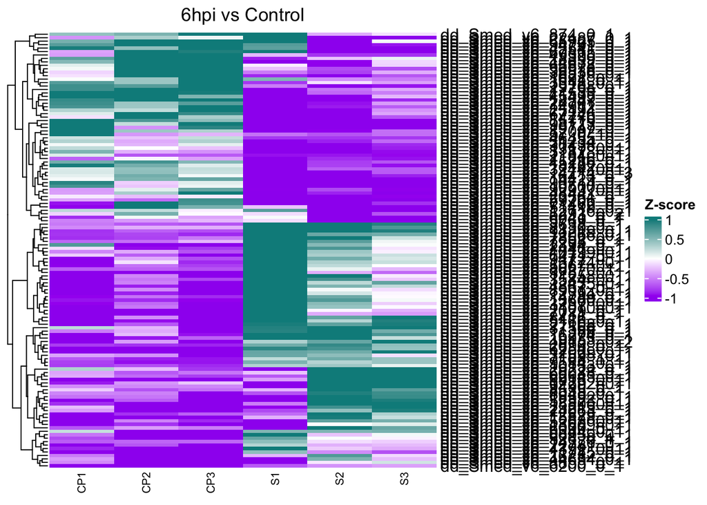

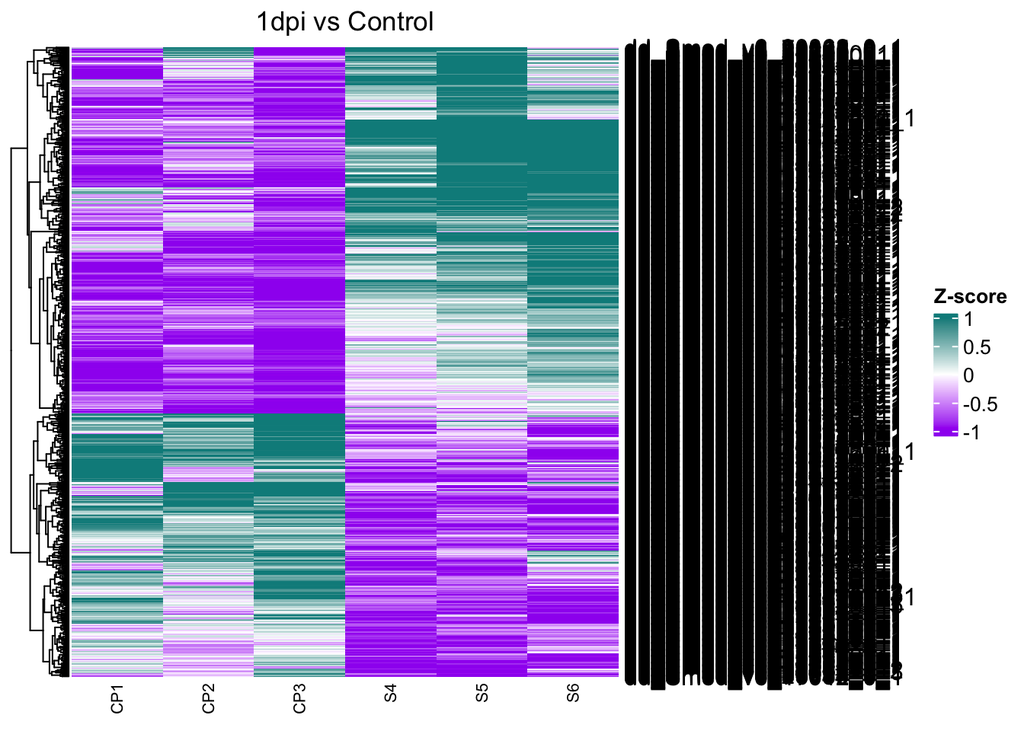

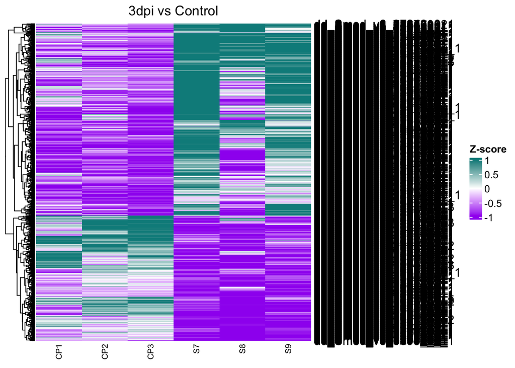

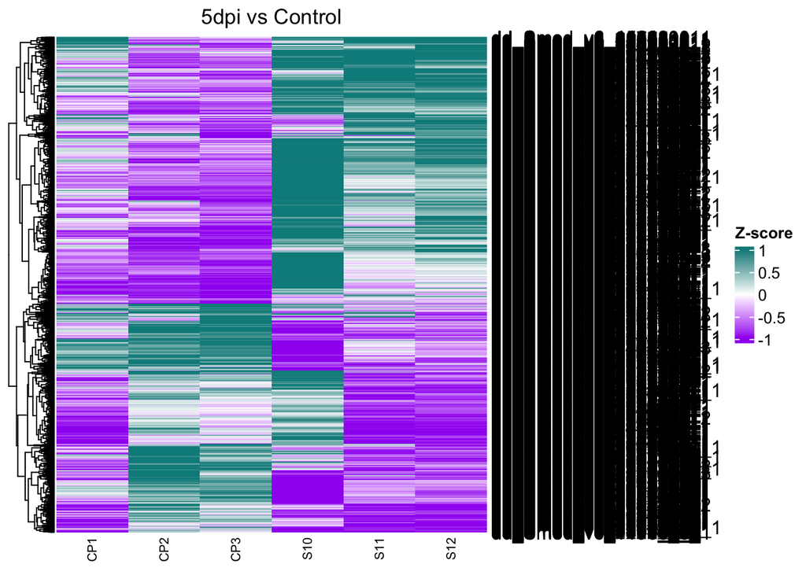

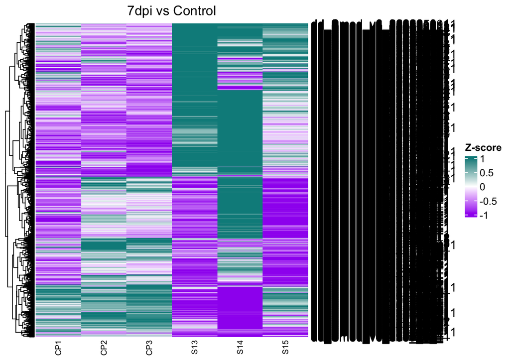

```r
mycolz <- colorRamp2(c(-1, 0, 1), c("purple", "white", "dark cyan"))

for (tp in timepoints) {
    df <- sig[[tp]]$all  # swap to sig[[tp]]$up / $down / $both for fold-change-thresholded versions

    if (nrow(df) == 0) {
        message(tp, ": no significant genes at FDR < 0.05 -- skipping heatmap.")
        next
    }

    sample_cols <- setdiff(colnames(df), stat_cols)
    mat <- as.matrix(df[, sample_cols])
    storage.mode(mat) <- "numeric"
    rownames(mat) <- make.unique(rownames(mat))

    hm <- Heatmap(mat, name = "Z-score", col = mycolz, column_title = paste0(tp,
        " vs Control"), column_names_gp = gpar(fontsize = 8),
        cluster_columns = FALSE, cluster_rows = TRUE)

    print(hm)

    pdf(paste0(analysis_date, "_Calbicans_", tp, "vControl_heatmap.pdf"),
        width = 6, height = 10)
    draw(hm)
    dev.off()
}
```

## Finding significant genes shared across all time points

```r
# The original script found genes shared across all 5
# contrasts by chaining pairwise merge.data.frame() calls
# (2 vs 3, then 4 vs 6, then combining those, then adding
# the last one). Besides being hard to follow, repeated
# merges on tables that share column names (logFC,
# adj.P.Val, etc.) produce auto-suffixed columns like
# 'C01.x.x' that later code had to carefully reconstruct.
# Intersecting gene IDs directly avoids that entirely.
shared_ids <- list(all = Reduce(intersect, lapply(timepoints,
    function(tp) rownames(sig[[tp]]$all))), up = Reduce(intersect,
    lapply(timepoints, function(tp) rownames(sig[[tp]]$up))),
    down = Reduce(intersect, lapply(timepoints, function(tp) rownames(sig[[tp]]$down))),
    both = Reduce(intersect, lapply(timepoints, function(tp) rownames(sig[[tp]]$both))))

# Per-contrast logFC/adj.P.Val for the shared gene set,
# with contrast-specific column names built directly from
# the topTables (which are already indexed by gene ID) --
# no merging required, and no suffix collisions to untangle
# afterward.
build_stats_summary <- function(gene_ids) {
    stats_by_tp <- lapply(timepoints, function(tp) {
        df <- toptables[[tp]][gene_ids, c("logFC", "adj.P.Val")]
        colnames(df) <- paste0(c("logFC_", "adjP_"), tp)
        df
    })
    do.call(cbind, stats_by_tp)
}

stats_summary_all <- build_stats_summary(shared_ids$all)
stats_summary_both <- build_stats_summary(shared_ids$both)
```

## Cleaning the shared-gene matrices and building supplemental heatmaps

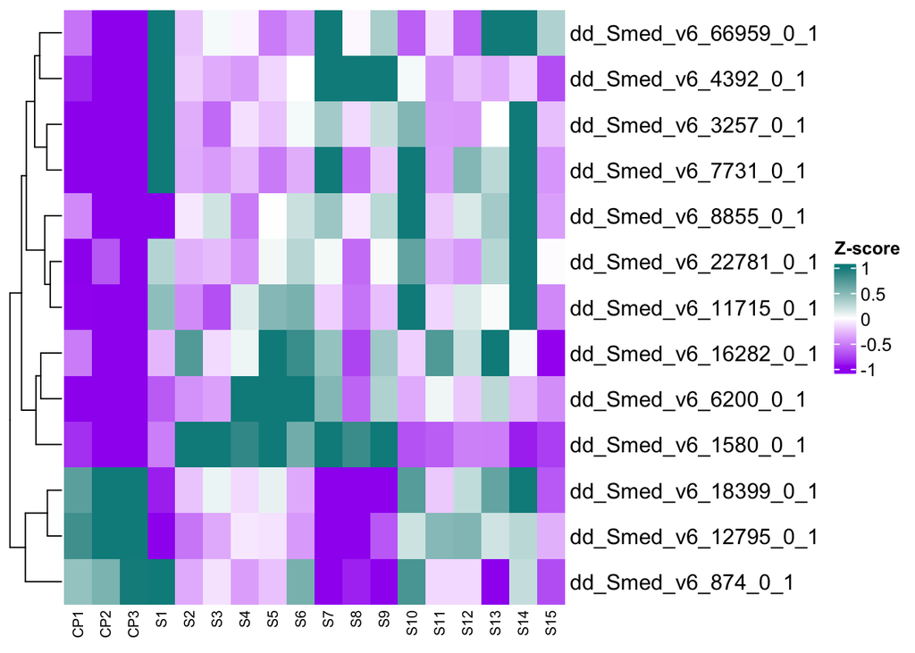

```r
zscore_matrix_all <- as.matrix(CPMzt[shared_ids$all, ])
zscore_matrix_both <- as.matrix(CPMzt[shared_ids$both, ])

write.csv(cbind(stats_summary_all, zscore_matrix_all), file = paste0(analysis_date,
    "_Calbicans_5contrasts_sharedsigDE_FDR0.05.csv"))
write.csv(cbind(stats_summary_both, zscore_matrix_both), file = paste0(analysis_date,
    "_Calbicans_5contrasts_sharedsigDE_LogFC1_FDR0.05.csv"))

mycolz <- colorRamp2(c(-1, 0, 1), c("purple", "white", "dark cyan"))

# make.unique() guards against duplicate gene IDs (e.g.
# multi-mapped annotations) breaking ComplexHeatmap's row
# labeling
rownames(zscore_matrix_all) <- make.unique(rownames(zscore_matrix_all))
rownames(zscore_matrix_both) <- make.unique(rownames(zscore_matrix_both))

hm_all <- Heatmap(zscore_matrix_all, name = "Z-score", col = mycolz,
    column_names_gp = gpar(fontsize = 8), cluster_columns = FALSE,
    cluster_rows = TRUE)
hm_both <- Heatmap(zscore_matrix_both, name = "Z-score", col = mycolz,
    column_names_gp = gpar(fontsize = 8), cluster_columns = FALSE,
    cluster_rows = TRUE)

hm_all
```

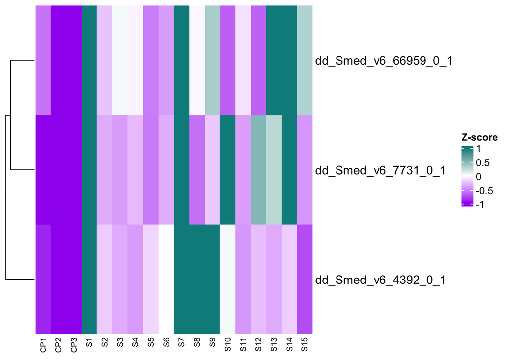

```r
hm_both
```

```r
pdf(paste0(analysis_date, "_Calbicans_sharedsigDE_heatmap_all.pdf"),
    width = 8, height = 10)
draw(hm_all)
dev.off()
```

```r
pdf(paste0(analysis_date, "_Calbicans_sharedsigDE_heatmap_LogFC1.pdf"),
    width = 8, height = 10)
draw(hm_both)
dev.off()
```

*Note: the original script wrote these z-score matrices to a `.txt` file and immediately re-read them back in with `read.delim()` before plotting, apparently to force the values to be treated as numeric. That round trip through disk isn’t needed – `as.matrix()` on the already-numeric CPM z-scores above accomplishes the same thing directly in memory.*

## Verifying the statistical significance of dd_smed_v6_2394_0_1 at each timepoint

```r
gene_id <- "dd_smed_v6_2394_0_1"

# Was it in the raw counts, and did it survive the
# low-count filter?  (these are the same regardless of
# timepoint, so only need to check once)
grep(gene_id, rownames(countsmat), ignore.case = TRUE, value = TRUE)
```

```
[1] "dd_Smed_v6_2394_0_1"
```

```r
grep(gene_id, rownames(dge_list), ignore.case = TRUE, value = TRUE)
```

```
[1] "dd_Smed_v6_2394_0_1"
```

```r
# Stats and FDR 0.05 significance for this gene across
# every timepoint vs Control
gene_report <- lapply(timepoints, function(tp) {
    match_id <- grep(gene_id, rownames(toptables[[tp]]), ignore.case = TRUE,
        value = TRUE)

    if (length(match_id) == 0) {
        return(data.frame(timepoint = tp, gene_id = NA, logFC = NA,
            adj.P.Val = NA, significant_FDR0.05 = NA))
    }
    if (length(match_id) > 1) {
        warning(tp, ": multiple gene IDs matched -- check for near-duplicate IDs: ",
            paste(match_id, collapse = ", "))
    }

    stats <- toptables[[tp]][match_id[1], c("logFC", "adj.P.Val")]
    data.frame(timepoint = tp, gene_id = match_id[1], logFC = stats$logFC,
        adj.P.Val = stats$adj.P.Val, significant_FDR0.05 = stats$adj.P.Val <
            0.05)
})

gene_report <- do.call(rbind, gene_report)
gene_report
```

```
  timepoint             gene_id     logFC    adj.P.Val significant_FDR0.05
1      6hpi dd_Smed_v6_2394_0_1  2.608514 0.0122256344                TRUE
2      1dpi dd_Smed_v6_2394_0_1  2.704726 0.0015467803                TRUE
3      3dpi dd_Smed_v6_2394_0_1  2.710027 0.0007701021                TRUE
4      5dpi dd_Smed_v6_2394_0_1  1.823932 0.0137946840                TRUE
5      7dpi dd_Smed_v6_2394_0_1 -1.313932 0.2109491340               FALSE
```

## Creating the venn diagram

```r
dt <- decideTests(vfit, p.value = 0.05, lfc = 1)
summary(dt)
```

```
       6hpi_vs_Control 1dpi_vs_Control 3dpi_vs_Control 5dpi_vs_Control
Down                32              98             190             384
NotSig           21843           21648           21440           21270
Up                  20             149             265             241
       7dpi_vs_Control
Down               562
NotSig           21056
Up                 277
```

```r
venn_pdf <- paste0(analysis_date, "_Calbicans_VennDiagram_6hpitoDay7.pdf")

venn_plot_args <- list(dt, include = c("up", "down"), counts.col = c("dark cyan",
    "purple"), circle.col = c("red", "blue", "green3", "magenta",
    "black"), mar = rep(1, 4), cex = c(1.5, 1.2, 0.5))

pdf(file = venn_pdf)
do.call(vennDiagram, venn_plot_args)
dev.off()
```

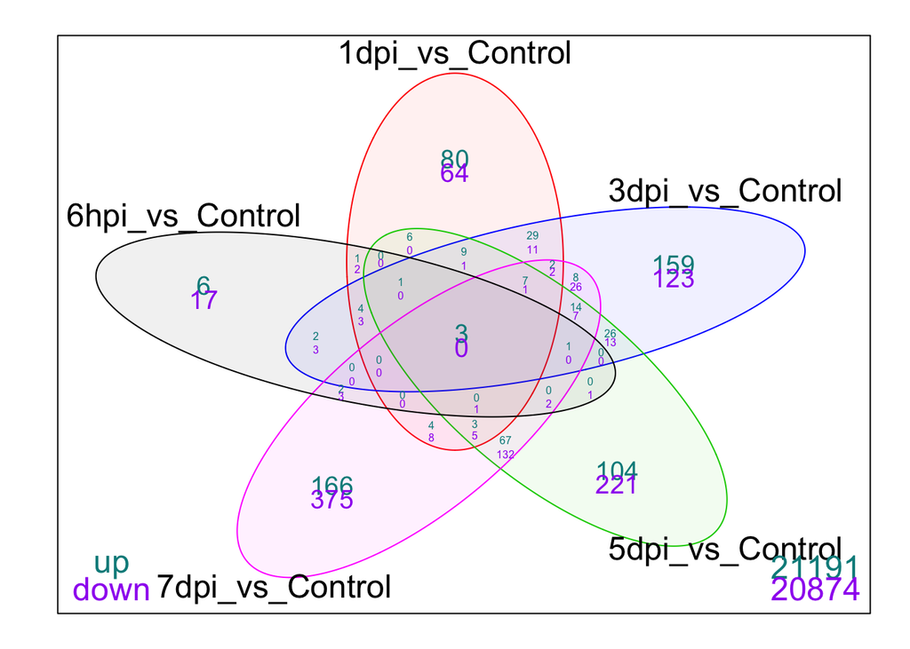

```r
# Also draw it inline so it shows up in the knitted
# document / plot pane
do.call(vennDiagram, venn_plot_args)
```